# Lab1, Parte 4: Correlações

Alice Fernandes Silva

Desde o uso das novas tecnologias nas eleições americanas de 2008, o Twitter tem se tornado uma plataforma para as atividades políticas, criando um canal para a interação entre políticos e eleitores. A comunicação política com o uso de mídia social é parte das atividades congressistas nos dias atuais. Além disto, o Twitter se constitui como importante meio para o ganho de popularidade com fins eleitorais.

O cenário político brasileiro não é diferente e a cada dia nossos parlamentares estão mais ativos nas redes sociais.

Utilizando os dados dos parlamentares da câmara, do partido PSL e os que possuem um perfil no twitter, é possível analisar a correlação entre algumas variáveis através de visualizações e transformações.

```r
atividade = read_projectdata() %>%
 filter(casa == "câmara") %>%
  filter(partido == "PSL") %>%
  filter(twitter != "NA")
glimpse(atividade)
```

```
## Observations: 44
## Variables: 19
## $ id_parlamentar        <chr> "204521", "204545", "204544", "204374", "2…
## $ casa                  <chr> "câmara", "câmara", "câmara", "câmara", "c…
## $ nome_eleitoral        <chr> "ABOU ANNI", "ALÊ SILVA", "ALEXANDRE FROTA…
## $ partido               <chr> "PSL", "PSL", "PSL", "PSL", "PSL", "PSL", …
## $ UF                    <chr> "SP", "MG", "SP", "DF", "RS", "MG", "SP", …
## $ twitter               <chr> "abouannipv", "oficialalesilva", "alefrota…
## $ seguidores            <dbl> NA, 464, 161745, 81544, NA, 7575, 103029, …
## $ segue                 <dbl> NA, 267, 2015, 742, NA, 63, 156, 907, 91, …
## $ n_proprio             <dbl> 0, 39, 830, 368, 0, 38, 776, 533, 13, 44, …
## $ n_retweet             <dbl> 0, 4, 169, 625, 0, 3, 223, 134, 4, 3, 0, 2…
## $ engaj_total           <dbl> 0, 10231, 566011, 1893839, 0, 46227, 33101…
## $ engaj_total_proprio   <dbl> 0, 186, 320063, 717602, 0, 21803, 2822907,…
## $ engaj_total_retweet   <dbl> 0, 10045, 245948, 1176237, 0, 24424, 48723…
## $ engaj_mediano         <dbl> 0.0, 4.0, 134.0, 773.0, 0.0, 243.0, 848.0,…
## $ engaj_mediano_proprio <dbl> 0, 4, 60, 0, 0, 182, 88, 65, 103, 2, 0, 10…
## $ engaj_mediano_retweet <dbl> 0, 0, 0, 202, 0, 0, 0, 0, 0, 0, 0, 0, 0, 0…
## $ engaj_max             <dbl> 0, 8171, 20348, 52614, 0, 19559, 33584, 19…
## $ engaj_max_proprio     <dbl> 0, 14, 7271, 27501, 0, 9516, 33584, 13034,…
## $ engaj_max_retweet     <dbl> 0, 8171, 20348, 52614, 0, 19559, 28088, 19…
```

# Qual a correlação entre engajamento total próprio e engajamento total de retweets dos deputados do PSL?

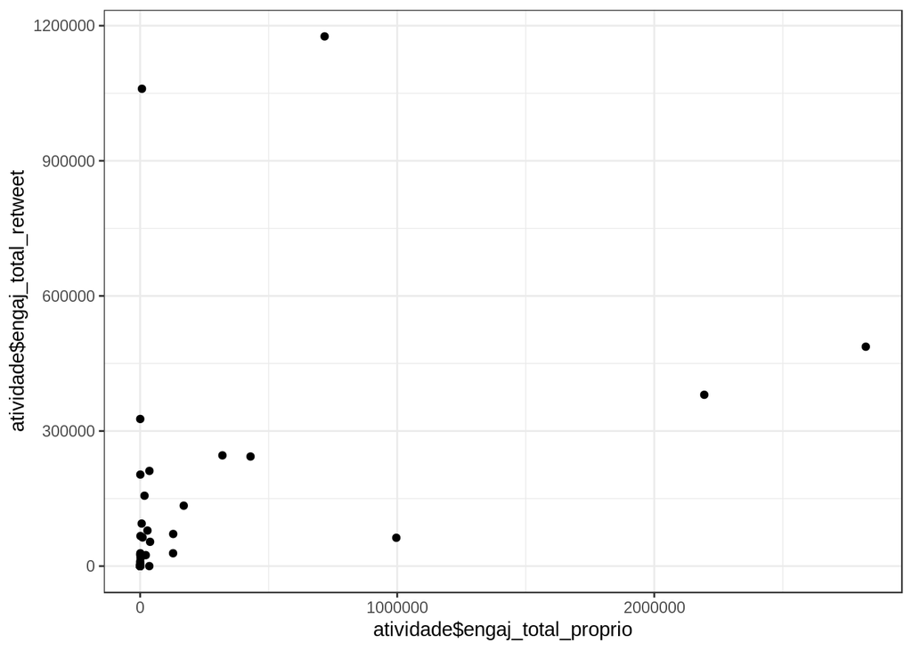

```r
atividade %>%
  ggplot(mapping = aes(x = atividade$engaj_total_proprio, y = atividade$engaj_total_retweet))+
  geom_point()
```

Vemos pela visualização acima que há uma concentração de deputados que possuem pouco engajamento total proprio e pouco engajamento total de retweet, com essa escala fica dificl de analisar se uma variável influencia na outra. Transformando os dois eixo em escala de log, temos a seguinte visualização:

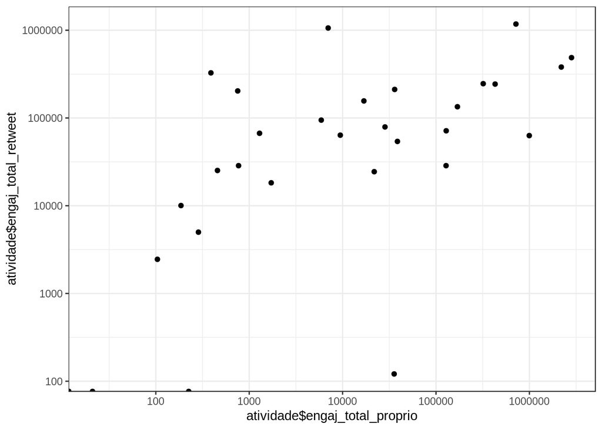

```r
atividade %>%
  ggplot(mapping = aes(x = atividade$engaj_total_proprio, y = atividade$engaj_total_retweet))+
  scale_x_log10() +
  scale_y_log10() +
  geom_point()
```

```r
atividade %>%
  summarise(correlacao = cor(engaj_total_proprio, engaj_total_retweet, method = "pearson"))
```

| correlacao |
| --- |
| 0.4045525 |

# Qual a correlação entre seguidores e engajamento máximo dos deputados do PSL?

```r
atividade_ = atividade %>%
  filter(seguidores != "NA")

glimpse(atividade_)
```

```
## Observations: 29
## Variables: 19
## $ id_parlamentar        <chr> "204545", "204544", "204374", "204520", "2…
## $ casa                  <chr> "câmara", "câmara", "câmara", "câmara", "c…
## $ nome_eleitoral        <chr> "ALÊ SILVA", "ALEXANDRE FROTA", "BIA KICIS…
## $ partido               <chr> "PSL", "PSL", "PSL", "PSL", "PSL", "PSL", …
## $ UF                    <chr> "MG", "SP", "DF", "MG", "SP", "RJ", "SC", …
## $ twitter               <chr> "oficialalesilva", "alefrotabrasil", "Biak…
## $ seguidores            <dbl> 464, 161745, 81544, 7575, 103029, 23127, 5…
## $ segue                 <dbl> 267, 2015, 742, 63, 156, 907, 91, 429, 463…
## $ n_proprio             <dbl> 39, 830, 368, 38, 776, 533, 13, 44, 228, 3…
## $ n_retweet             <dbl> 4, 169, 625, 3, 223, 134, 4, 3, 27, 79, 3,…
## $ engaj_total           <dbl> 10231, 566011, 1893839, 46227, 3310137, 67…
## $ engaj_total_proprio   <dbl> 186, 320063, 717602, 21803, 2822907, 42940…
## $ engaj_total_retweet   <dbl> 10045, 245948, 1176237, 24424, 487230, 243…
## $ engaj_mediano         <dbl> 4.0, 134.0, 773.0, 243.0, 848.0, 309.0, 12…
## $ engaj_mediano_proprio <dbl> 4, 60, 0, 182, 88, 65, 103, 2, 10, 3, 7, 7…
## $ engaj_mediano_retweet <dbl> 0, 0, 202, 0, 0, 0, 0, 0, 0, 0, 0, 0, 15, …
## $ engaj_max             <dbl> 8171, 20348, 52614, 19559, 33584, 19730, 1…
## $ engaj_max_proprio     <dbl> 14, 7271, 27501, 9516, 33584, 13034, 340, …
## $ engaj_max_retweet     <dbl> 8171, 20348, 52614, 19559, 28088, 19730, 1…
```

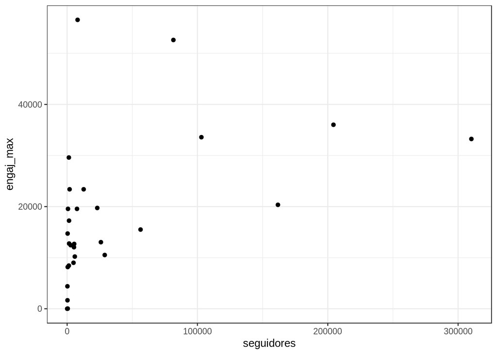

```r
atividade_ %>%
  ggplot(mapping = aes(x = seguidores, y = engaj_max))+
  geom_point()
```

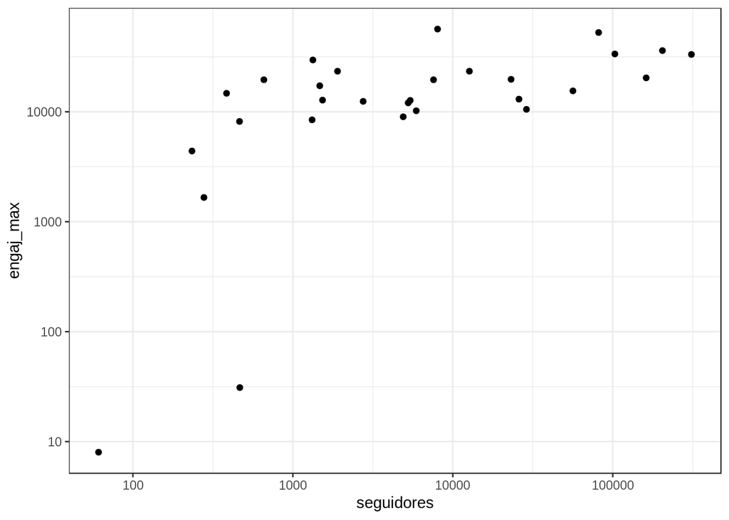

```r
atividade_ %>%
  ggplot(mapping = aes(x = seguidores, y = engaj_max))+
  geom_point()+
  scale_x_log10()+
  scale_y_log10()
```

Com a transformação realizada, temos que, existe uma relação linear entre as duas variáveis em questão, porém essa correlação é fraca e positiva. Existem pontos extremos na relação entre essas variáveis em que o número de seguiodres é baixo, porém o engajamento maximo é muito alto. Vale salientar que a maioria dos pontos possuem engajamento maximo maior que 10000.

```r
atividade_ %>%
  summarise(correlacao = cor(seguidores, engaj_max, method = "pearson"))
```

| correlacao |
| --- |
| 0.4501042 |